# Cancer incidence in NHS Borders

## Introduction

- Incidence is the registration of new cases of cancer, and so is an indicator of incoming patients looking for treatment. It is not an indicator of the number of clients surviving with cancer over the long-term (for that, use prevalence).
- NHS Borders sits within the South East regional network (SCAN) alongside NHS Dumfries & Galloway, NHS Fife and NHS Lothian (where the Cancer Centre for this region is hosted). Overall, this network provides services to ~1.5 million people.

To better understand incidence of cancer in NHS Borders, I have analysed:

- In recent years, which types of cancer have been diagnosed in people resident in NHS Borders? For whom do they present (sex and age)?
- For the type of cancer with the highest rates, how does the incidence rate in NHS Borders compare to the region and to Scotland as a whole? What is the trend over time?

This analyses uses open data about [annual cancer incidence](https://www.opendata.nhs.scot/dataset/annual-cancer-incidence) (last updated 29 March 2023) available from Public Health Scotland, which contains public sector information licensed under the [Open Government Licence v3.0](https://www.nationalarchives.gov.uk/doc/open-government-licence/version/3/) - but does not contain identifiable information. Of note, it is not possible to examine incidence rate of multiple cancers in individual patients.

## Cancer types for females in NHS Borders

Some cancers are sex-specific, so I have analysed incidence of cancer sites separately for males and females.

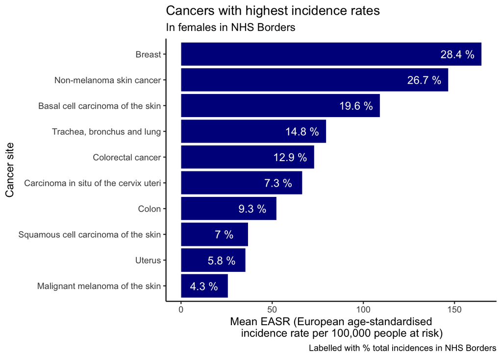

For females in NHS Borders, the 10 cancer sites with the highest incidence include breast, cervical and uterine cancers, as well as skin cancers*, lung cancer and intestinal cancers.

The highest occurring new (diagnosed) cancers in females in NHS Borders in the past 5 years (2017-2021) were breast (28%) and non-melanoma skin cancers (27%).

*Note that basal cell and squamous cell carcinomas are both types of non-melanoma skin cancers.

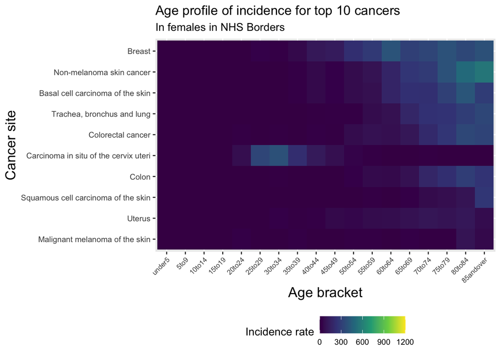

## Cancer types for males in NHS Borders

[figure not shown]

In males, skin cancers also feature amongst the highest incidence in NHS Borders, as well as prostate cancer, intestinal cancers and lung cancer. In 2017-2021, 47% of cancers in males were non-melanoma skin cancers, and 26% were prostate cancer.

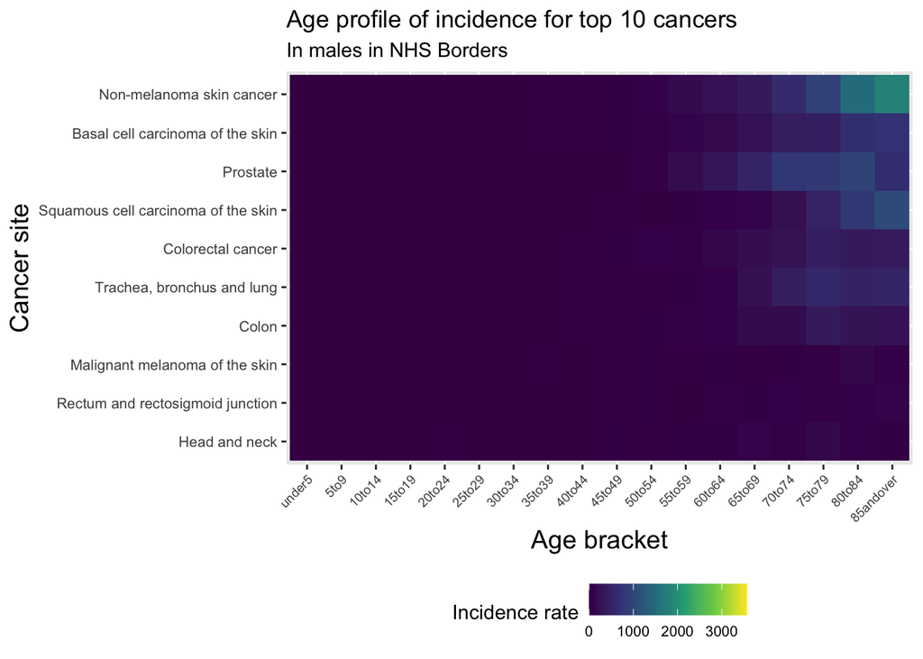

All of these cancers are presenting in older age groups, the data suggests that screening for these cancers will be important from around the age of 60-65 years.

## Non-melanoma skin cancer trends

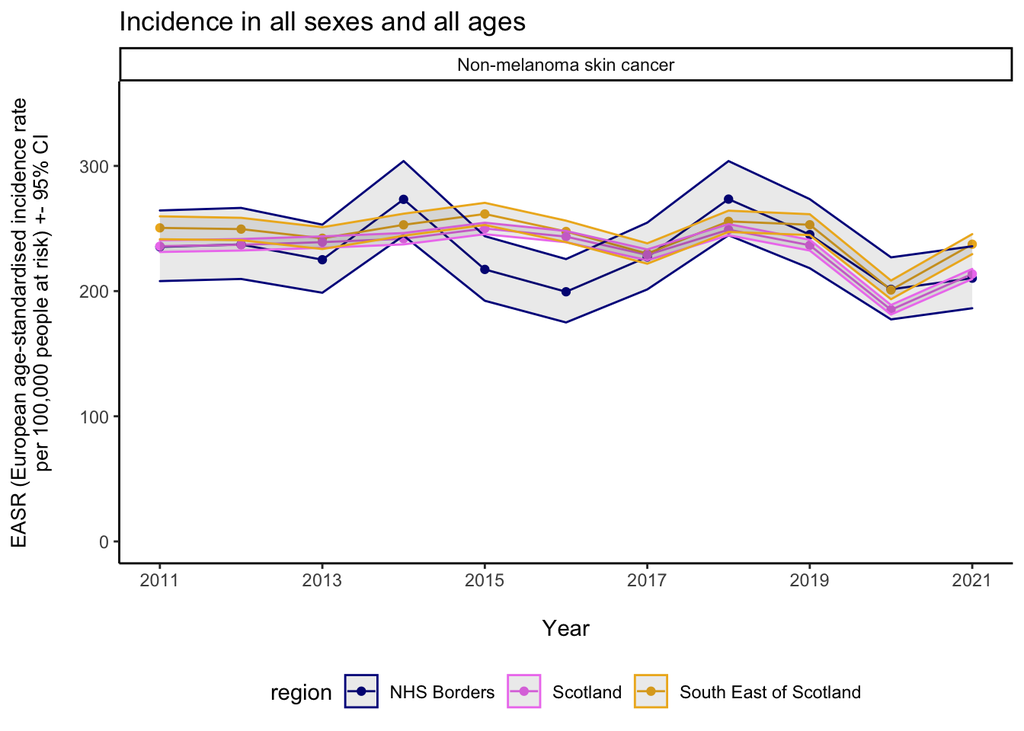

```r
incidence_easr %>%
  filter(year >= 2011 &
           sex == "All" &
        cancer_site == "Non-melanoma skin cancer") %>%
  ggplot(aes(x = year, y = easr, colour = region)) +
  geom_line() +
  geom_point() +
  scale_colour_manual(values = c("darkblue", "violet", "goldenrod2")) +
  geom_ribbon(aes(ymin = easr_lower95pc_confidence_interval,
                  ymax = easr_upper95pc_confidence_interval,
                  colour = region), alpha=0.1) +
  scale_y_continuous(limits = c(0, 350)) +
  scale_x_continuous(breaks = c(2011, 2013, 2015, 2017, 2019, 2021, 2023)) +
  labs(y = "EASR (European age-standardised incidence rate
       per 100,000 people at risk) +- 95% CI\n",
       x = "\nYear",
       title = "Incidence in all sexes and all ages") +
  theme_classic() +
  theme(legend.position = "bottom",
        axis.title.y = element_text(size = 10)) +
  facet_wrap(~ cancer_site)
```

As noted above, non-melanoma skin cancer is of high incidence in both male and females. Comparing NHS Borders with the South East region and Scotland in general for all ages, we can see that the overall trend is approximately the same as the regional network and national rates, with no obvious increase/decrease over time - potentially a drop in diagnoses during 2020-2021 due to impact of COVID-19 pandemic on service provision.

It is worth noting that incidence in NHS Borders is more variable than the regional and national averages, and also that the SCAN Network (which includes the Borders) looks to have a consistently higher incidence rate of this type of skin cancer than Scotland overall - and so the network should consider ensuring there is adequate provision for treatment of this cancer, particularly in older age groups (both males and females)

## Conclusions

Based on the available data, I recommend considering planning to ensure sufficient:

- Screening for **males and females over 60 years of age for non-melanoma skin cancers (BCC and SCC)**, which were the most frequently occurring new registrations of cancer in 2017-2021 in NHS Borders. These cancers may occur more frequently in the South East network than in Scotland overall, so there may be a targeted plan of action for SCAN that NHS Borders services can leverage. It may also be beneficial to increase education about how to protect ourselves from UV exposure, which is the main cause of these cancers ([NHS UK](https://www.nhs.uk/conditions/non-melanoma-skin-cancer/)).
- Screening for **women aged 50+ for breast cancer**, **women aged 25-40 years for cervical cancer**, and **men aged 55+ for prostate cancer** (also high incidence rates).
- To further inform planning of services, consider analysing:
  - incidence, prevalence and service provision by **deprivation** (SIMD) and **race** to understand whether current services support equitable healthcare
  - current [cancer treatment wait times](https://www.opendata.nhs.scot/dataset/cancer-waiting-times), especially for non-melanoma skin, breast and prostate cancers
  - analyse cancer incidence for people aged under 75 to focus on cancers appearing earlier than expected than from ageing risk alone